# The Inequity Z: Income Fairness Perceptions in Europe Across the Income Distribution

Fabian Kalleitner

Sandra Bohmann

2023-02-23

# Abstract

Using data from the European Social Survey, this visualization examines income fairness evaluations of 17,605 respondents from 28 countries. Respondents evaluated the fairness of their own income as well as the fairness of the income of the top and bottom income decile in their country. Depicted on a single graph, these income fairness evaluations take on a Z-shaped form, which we call the “inequity Z”. The inequity Z reveals an extensive level of consensus within each country regarding the degree of unfairness of top and bottom incomes. With rising income, respondents consistently judge their own income to be less unfair. Across countries, the gap in fairness ratings between top and bottom incomes rises with income inequality. Perceived underreward of bottom incomes is more pronounced in countries where bottom incomes are objectively lower. Thus, our visualization suggests, when confronted with information about actual income levels, perceived inequity increases with inequality.

### Keywords

income fairness, inequality, social justice, Europe

Scientific evidence shows that people accept certain levels of inequality, favoring equity over equality (Starmans 2017). But how much inequality is fair, and is unfair inequality related to objective inequality? The normative approach to answering this question estimates unfair inequality based on justice principles, including equality of opportunity and freedom from poverty (Ahrens 2022; Hufe et al. 2022). Instead, we take an empirical approach, using European Social Survey (ESS) data that asked individuals directly about their perceived fairness of own, bottom, and top incomes in a number of countries.

We use data from round 9 of the ESS fielded in 2019 in 29 European countries. Respondents were asked to rate the fairness of their own gross income, as well as the fairness of earnings of the top and bottom gross income deciles of full-time employees in their country on a scale ranging from extremely unfairly too low (-4) to extremely unfairly too high (+4). Importantly, respondents were informed about the absolute values of these top and bottom incomes ahead of the fairness evaluation. Our final sample includes only individuals currently employed or self-employed (n=17,605). Additional details are available in the Online Supplement; data access and replication code are available at https://github.com/fabiankal/inequityZ.

Figure 1 depicts all three fairness evaluations by respondents’ gross income in a single graph yielding a Z-shaped form that we call the “inequity Z”. The Z symbolizes the three main characteristics of the relationship between respondents’ fairness evaluations and income: widespread agreement across different income groups that (1) bottom incomes are too low; and (2) top incomes are too high; as well as (3) a nearly linear increase in fairness ratings of own income with rising levels of income. Most astonishingly, different income groups not only agree on the direction of the unfairness but, also on the degree of unfairness. This is particularly true for the degree to which bottom-income earners are perceived to be unfairly underpaid. Contrary to that, top incomes are evaluated slightly more just in higher income deciles in several countries, potentially revealing increasing levels of beliefs in meritocracy with rising levels of income.

[figure not shown]

**Figure 1:** Average fairness evaluation of own gross income (red), the lower bound of the top gross income decile (black), and the upper bound of the bottom income decile (green) by country and respondents’ income position. Respondents were informed about the respective absolute income levels of the top and bottom income decile of full-time employees in their country and could evaluate the respective incomes on a 9-point rating scale ranging from extremely unfairly too low (-4) to extremely unfairly too high (+4). Individual-level poststratification and design weights provided by the ESS are applied throughout the analyses. Countries are categorized into six groups depending on the level of inequality as measured by the P90/P10 income ratio of full-time employees (right axis). Within each inequality group, countries are sorted by the dollar-equivalized purchasing power of the bottom income decile of full-time employees. Source: European Social Survey Round 9 (ESS Eric, 2021), own calculations. Note: Additional details are available in the ONLINE SUPPLEMENT. A replication package for this figure using R is available at https://github.com/fabiankal/inequityZ. The data can be downloaded from the ESS website (the link is provided in the replication package).

While the Z shape can be replicated in every country in the ESS, the spread of the Z differs between countries: in more equal countries, the fairness gap between top- and bottom income fairness ratings is smaller as both, on average, approach the level of absolute fairness (Pearson’s correlation: 0.57, p=0.002). In countries where the bottom income decile has a comparatively low purchasing power (i.e. where relative poverty approaches absolute poverty) bottom income earners are evaluated as more underrewarded compared to countries where the purchasing power of low incomes is higher (Pearson’s correlation: 0.82, p<0.001).

Previous research suggests that the link between inequity and inequality might be weak because meritocratic beliefs tend to increase with inequality (Heisermann et al. 2017; Mijs 2021) and because fairness assessments are anchored in the status quo (Trump 2018). We find that, despite these mechanisms, respondents’ fairness evaluations still change with the amount of inequality and poverty in their country. Thus, when confronted with information about actual income levels, perceived inequity increases with inequality. Moreover, respondents with very diverse personal incomes largely agree that bottom incomes are much too low and top incomes are slightly too high. Thus, different income classes provide astonishingly similar fairness assessments of bottom and top incomes in many European countries.

# References

Ahrens, Leo. 2022. “Unfair Inequality and the Demand for Redistribution: Why Not All Inequality Is Equal.” *Socio-Economic Review* 20(2):463–87. doi: 10.1093/ser/mwaa051.

European Social Survey European Research Infrastructure (ESS ERIC). 2021. ESS9 - integrated file, edition 3.1 [Data set]. Sikt - Norwegian Agency for Shared Services in Education and Research.https://doi.org/10.21338/ESS9E03_1

Heiserman, Nicholas, and Brent Simpson. 2017. “Higher Inequality Increases the Gap in the Perceived Merit of the Rich and Poor.” *Social Psychology Quarterly* 80(3):243–53. doi: 10.1177/0190272517711919.

Hufe, Paul, Ravi Kanbur, and Andreas Peichl. 2022. “Measuring Unfair Inequality: Reconciling Equality of Opportunity and Freedom from Poverty.” *The Review of Economic Studies* 89(6):3345–80. doi: 10.1093/restud/rdab101.

Mijs, Jonathan J. B. 2021. “The Paradox of Inequality: Income Inequality and Belief in Meritocracy Go Hand in Hand.” *Socio-Economic Review* 19(1):7–35. doi: 10.1093/ser/mwy051.

Starmans, Christina, Mark Sheskin, and Paul Bloom. 2017. “Why People Prefer Unequal Societies.” *Nature Human Behaviour* 1(4):0082. doi: 10.1038/s41562-017-0082.

Trump, Kris-Stella. 2018. “Income Inequality Influences Perceptions of Legitimate Income Differences.” *British Journal of Political Science* 48(4):929–52. doi: 10.1017/S0007123416000326.

# Supplementary Material

The full replication code to rebuild the visualization is available [here](https://github.com/fabiankal/inequityZ).

## Data

Analyses are based on the ninth wave of the European Social Survey (ESS). The ESS is an international, bi-annually repeated cross-sectional survey study. In its ninth wave, which was fielded between September 2018 and January 2020, the ESS included a special module on perceptions of justice and fairness, collecting information from almost 50,000 respondents in 29 European countries. Surveys are conducted via CAPI in the respective language of the country.

## Measures

### Own/top/bottom income fairness

Respondents’ fairness evaluations of their own income was measured by the question: “Would you say your gross pay is unfairly low, fair, or unfairly high?”. Respondents could answer on a 9-point rating scale ranging from extremely unfairly too low (-4) to extremely unfairly too high (+4), with 0 indicating that the respondent considers the evaluated income as fair. The answer scale shown to the respondents is depicted in Figure A1.

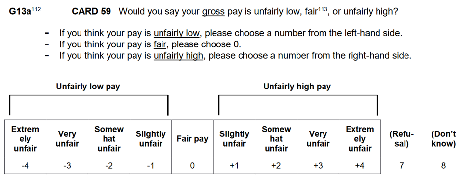

**Figure A1:** Response card for evaluation of own income. Source: European Social Survey 2018. ESS Round 9 Source Questionnaire. London: ESS ERIC Headquarters c/o City, University of London. available at: https://www.europeansocialsurvey.org/docs/round9/fieldwork/source/ESS9_source_questionnaires.pdf

Using the same scale, respondents were also asked to assess the fairness of the top and bottom 10% personal gross incomes of employees working full time in their country. The question wording also included the amount of these reference points in the national currency. Thus, answers are not biased by limited information on the actual earnings of these reference points. We also note that the focus on full time employees should also minimize the role of different beliefs about the deservingness of the poor.

### Income deciles

We use the full time equalized personal gross income decile as our main indicator for the respondent’s income position. This is calculated using respondent’s “usual weekly/monthly/annual gross pay before tax and compulsory deductions” as measured in their local currency. We chose this income indicator as it is closest to the income respondents were asked to assess in the items on the perceived fairness of incomes. We standardize the answers to the monthly income as this is the most frequently reported category. Afterwards, we divide the answers by respondents self-reported total weekly working hours and standardize it to 40 hours per week. In addition, we impute the mid-point of the corresponding income category for respondents who did not provide income in absolute values but responded to a subsequent question asking for incomes in 10 categories representing countrywide income deciles. We use the median income of the top income decile of the continuous question as a proxy for the level of the top open-ended income decile. Afterwards, we calculate country-specific income deciles to generate a measure for respondents’ relative income positions.

### Inequality and bottom income level

The level of actual inequality in a country is approximated by the p90/p10 ratio using the upper bound of the bottom income decile and the lower bound of the top income decile of full-time employees in the respective country. We do not calculate these income thresholds ourselves but use the same values that were included in the ESS questionnaire to assess respondents’ fairness evaluations of top and bottom incomes. Note, however, that due to the limited availability of coherent measures for these reference incomes, their sources varied by country (although most used the EU-SILC). For this reason and due to certain “outliers” (e.g. Austria and Slovakia have very low income estimates that do not seem to reflect the sources and income definition reported), the rankings of inequalities by country would look different if we had used other more coherent measures of inequality.

The “bottom income level” is measured using the upper bound of the bottom income decile of full-time employees in each country. Again, we do use the values that were used in the ESS questionnaire but transform these to dollar equivalents using purchasing power parities (World Bank 2022) to gain a measure of low income that is comparable across countries.

## Sample

We use the full set of countries available to us as of ESS’s 3.1 release of the data, except for Cyprus, for which information on work hours is missing (see ESS9 Data Documentation Report). Because we focus primarily on those actively participating in the labor market, we only use individuals currently employed or self-employed. This approach is also necessary because the wording of all justice items we are using differed for those retired or receiving social security benefits. After listwise deletion of missing values, the sample comprises 17,605 individuals from 28 countries. Country samples range from 259 cases in Montenegro to 1036 cases in Germany (see Table A1).

**Table A1:** Final number of observations by country

| cntry | n |
| --- | --- |
| AT | 763 |
| BE | 817 |
| BG | 598 |
| CH | 641 |
| CZ | 859 |
| DE | 1036 |
| DK | 778 |
| EE | 1005 |
| ES | 558 |
| FI | 802 |
| FR | 779 |
| GB | 948 |
| HR | 455 |
| HU | 493 |
| IE | 719 |
| IS | 470 |
| IT | 526 |
| LT | 472 |
| LV | 340 |
| ME | 259 |
| NL | 741 |
| NO | 813 |
| PL | 428 |
| PT | 368 |
| RS | 370 |
| SE | 733 |
| SI | 526 |
| SK | 308 |

## Further tests

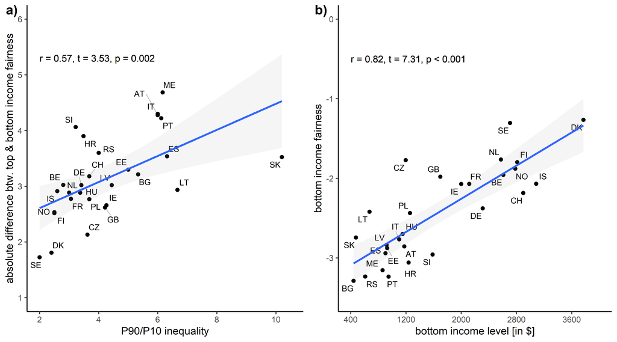

**Figure A2:** Correlation between inequality and fairness gap (a), bottom income level and bottom income fairness (b). Fairness evaluations can range from extremely unfairly too low (-4) to extremely unfairly too high (+4). Bottom income levels represent dollar equivalents calculated using purchasing power parities. The correlation coefficient r shows the Pearson’s correlation. Source: European Social Survey Round 9 (ESS Eric, 2021), own calculations.

Note that Slovakia is a clear outlier with regard to income inequality but excluding it from the sample only increases the correlation (r=0.66). Most likely the ESS miscalculated the reported income deciles for Slovakia. A likely error could be that they used all employees instead of only those working full-time. However, according to the ESS reports, all employees have only been used by Latvia (because other data was not available) and by Poland (which, however, calculated full-time equivalents before estimating the deciles). Hence, we emphasize that our results should be interpreted as evidence how people react to information of inequality and not necessarily how they react to inequality itself.

## References

World Bank. 2022. PPP conversion factor, GDP (LCU per international $). https://data.worldbank.org/indicator/PA.NUS.PPP